# Task 3 - Text Wrangling and Analysis

Matthieu Huy

2023-03-16

```r
knitr::opts_chunk$set(echo = TRUE, warning = FALSE, message = FALSE)
library(tidyverse)
library(here)
library(tidytext)
library(textdata)
library(pdftools)
library(ggwordcloud)
```

[figure not shown]

```r
knitr::include_graphics("/Users/matthuy/Desktop/Rprojects/ESM 244/esm244_a4_spatialdata_timeseries_textwrangling/kite_cover.jpg")
```

For the purpose of this text analysis, I will use one of my favorite novels, *The Kite Runner.* Afghan-American author Khaled Hosseini’s first novel is a coming-of-age story following the maturation of Amir, an Afghan male, through Afghanistan’s tumultuous recent history. It showcases life in Afghanistan prior to the soviet invasion, under soviet occupation, under Taliban rule, and under U.S. occupation. Inspired by Hosseini’s own experiences and family heritage, the novel explores themes such as class division, betrayal, religion, growing up, and similarities and differences between American and Afghan culture. For someone such as myself who knew very little about Afghanistan prior to reading the novel, *The Kite Runner.* shed light on the rich culture and people of a country that is often reduced down to its leaders (the Taliban), and associated terrorist groups.

In this analysis, I will observe the frequency and sentiment of words used in each chapter and the novel overall.

**Citation:** Hosseini, Khaled. *The Kite Runner*. Cambridge University Press, 2006.

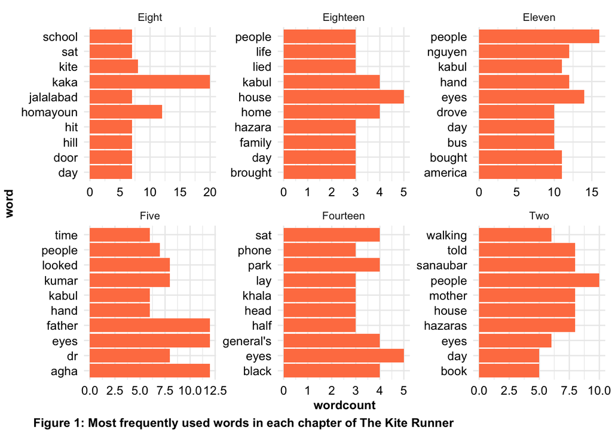

```r
kite_runner_text <- pdf_text(here('data/kite_runner.pdf'))

kr_lines <- data.frame(kite_runner_text) %>%
  mutate(page = 1:n()) %>%
  mutate(text_full = str_split(kite_runner_text, pattern = '\\n')) %>%  ### breaks up full page string into individual lines based on pattern "\n" at the end of each line
  unnest(text_full) %>%  ### turns each line, which we split, into its own row of the data frame
  mutate(text_full = str_trim(text_full)) ### eliminate excess spaces

chapts <- c("TWO|THREE|FOUR|FIVE|SIX|SEVEN|EIGHT|NINE|TEN|ELEVEN|TWELVE|THIRTEEN|FOURTEEN|FIFTEEN|SIXTEEN|SEVENTEEN|EIGHTEEN|NINETEEN|TWENTY|TWENTY-ONE|TWENTY-TWO|TWENTY-THREE|TWENTY-FOUR|TWENTY-FIVE")

kr_chapts <- kr_lines %>%
  slice(-(1:68)) %>%
  mutate(chapter = ifelse(str_detect(text_full, chapts), text_full, NA)) %>%
  fill(chapter, .direction = 'down') %>% #fill rest of column with extracted chapter until next chapter is reached
  mutate(chapter = str_to_title(chapter))

kr_words <- kr_chapts %>%
  unnest_tokens(word, text_full) %>%
  select(-kite_runner_text) %>%
  anti_join(stop_words, by = 'word')

kr_wordcounts <- kr_words %>%
  count(chapter, word) %>%
  filter(! word %in% c("soraya", "baba", "baba's", "khan", "rahim", "amir", "sohrab's", "sohrab", "hassan", "hassan's", "assef", "assef's", "farid", "karim", "ali"))
#remove names of characters

top_5_words <- kr_wordcounts %>%
  group_by(chapter) %>%
  arrange(-n) %>%
  slice(1:10) %>%
  ungroup() %>%
  filter(chapter %in% c("Two", "Five", "Eight", "Eleven", "Fourteen", "Eighteen", "Twenty-two", "Twenty-five"))

ggplot(data = top_5_words,
       aes(x = n,
           y = word)) +
  geom_col(fill = "coral") +
  facet_wrap(~chapter,
             scales = "free") +
  labs(x = "wordcount",
       caption = "Figure 1: Most frequently used words in each chapter of The Kite Runner") +
  theme_minimal() +
  theme(axis.text = element_text(color = "black", size = 10),
        axis.title.x = element_text(color = "black", size = 10, face = "bold"),
        axis.title.y = element_text(color = "black", size = 10, face = "bold",
                                    vjust = 2),
        plot.caption = element_text(hjust = -0.5, color = "black",
                                    size = 10, face = "bold"))
```